# Lab 1d: Species Distribution Modeling - Evaluate Models

2022-01-13

# 1 Learning Objectives

- Evaluate model performance
- Calibrate model parameters

# 2 Setup

- load packages
  - `dismo` - species distribution modeling: `maxent()`, `predict()`, `evaluate()`
  - `usdm` - uncertainty analysis for species distribution models: `vifcor()`
- set options
- set `ggplot` theme
- set directory paths
- read in the data
  - observation points
  - raster stack of environmental layers

```r
librarian::shelf(
  dismo, # species distribution modeling: maxent(), predict(), evaluate(),
  dplyr, ggplot2, GGally, here, maptools, readr,
  raster, readr, rsample, sf,
  usdm)  # uncertainty analysis for species distribution models: vifcor()
select = dplyr::select

set.seed(42)
options(
  scipen = 999,
  readr.show_col_types = F)
ggplot2::theme_set(ggplot2::theme_light())

dir_data      <- here("data")
pts_geo       <- file.path(dir_data, "pts.geojson")
env_stack_grd <- file.path(dir_data, "env_stack.grd")
mdl_maxv_rds  <- file.path(dir_data, "mdl_maxent_vif.rds")

pts <- read_sf(pts_geo)
env_stack <- raster::stack(env_stack_grd)
```

## 2.1 Split observation data into training and testing sets

- the training data set uses 80% of the data
- the testing data set uses the remaining 20% of the data

```r
pts_split  <- rsample::initial_split(
  pts, prop = 0.8, strata = "present")
pts_train  <- rsample::training(pts_split)
pts_test   <- rsample::testing(pts_split)

pts_train_p <- pts_train %>%
  filter(present == 1) %>%
  as_Spatial()
pts_train_a <- pts_train %>%
  filter(present == 0) %>%
  as_Spatial()
```

# 3 Calibrate: Model Selection

- use a pairs plot to check correlation between environmental variables and assess multicollinearity issues

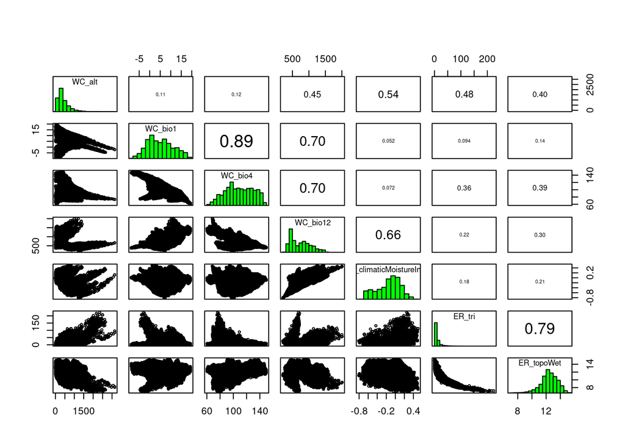

```r
pairs(env_stack)
```

## 3.1 Calculate variance inflation factor per predictor, a metric of multicollinearity between variables

```r
vif(env_stack)
```

```
##                  Variables       VIF
## 1                   WC_alt  5.298571
## 2                  WC_bio1 38.204099
## 3                  WC_bio4 12.440092
## 4                 WC_bio12 40.463815
## 5 ER_climaticMoistureIndex 23.037076
## 6                   ER_tri  3.481211
## 7               ER_topoWet  3.186877
```

## 3.2 Stepwise reduce predictors, based on a max correlation of 0.7

- conduct a multicollinearity reduction using `vifcor()`

```r
v <- vifcor(env_stack, th=0.7)
v
```

```
## 3 variables from the 7 input variables have collinearity problem:
##
## WC_bio1 ER_tri WC_bio12
##
## After excluding the collinear variables, the linear correlation coefficients ranges between:
## min correlation ( ER_climaticMoistureIndex ~ WC_bio4 ):  -0.07578153
## max correlation ( ER_climaticMoistureIndex ~ WC_alt ):  -0.5230374
##
## ---------- VIFs of the remained variables --------
##                  Variables      VIF
## 1                   WC_alt 2.259718
## 2                  WC_bio4 1.189175
## 3 ER_climaticMoistureIndex 1.989402
## 4               ER_topoWet 1.958484
```

## 3.3 Reduce the environmental raster stack by excluding variables that were too correlated

- visualize the remaining variables with another pairs plot

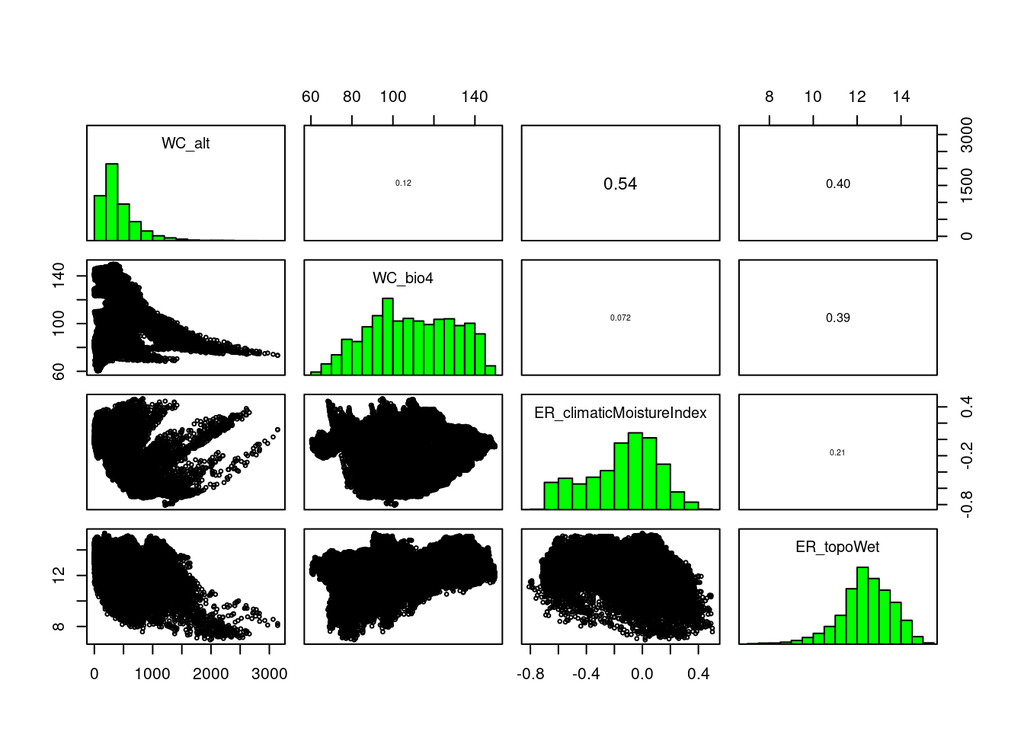

```r
env_stack_v <- usdm::exclude(env_stack, v)

pairs(env_stack_v)
```

## 3.4 Fit a maximum entropy model using `maxent()`

- plot variable contributions per predictor

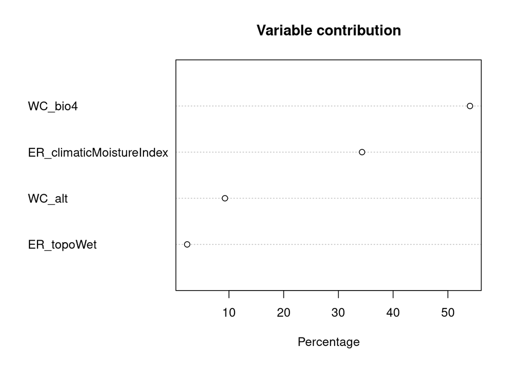

```r
pts_train_test <- pts_train %>%
  select(present, geometry)

if (!file.exists(mdl_maxv_rds)){
  mdl_maxv <- maxent(env_stack_v, pts_train)
  readr::write_rds(mdl_maxv, mdl_maxv_rds)
}
mdl_maxv <- read_rds(mdl_maxv_rds)

plot(mdl_maxv)
```

## 3.5 Plot term plots

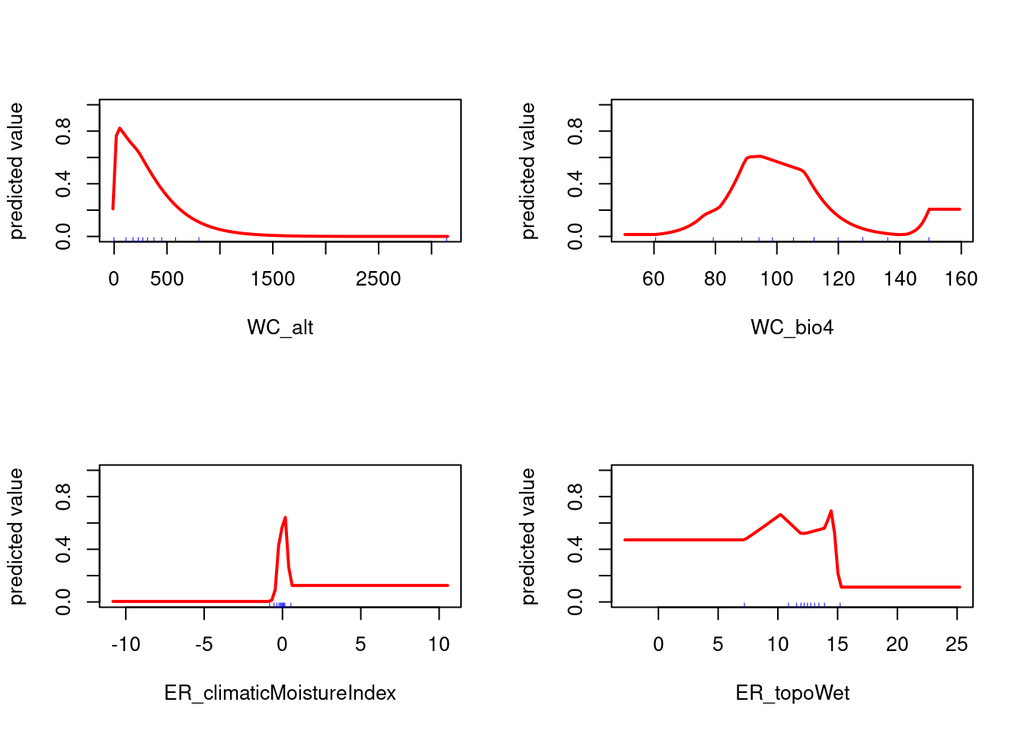

```r
response(mdl_maxv)
```

## 3.6 Predict

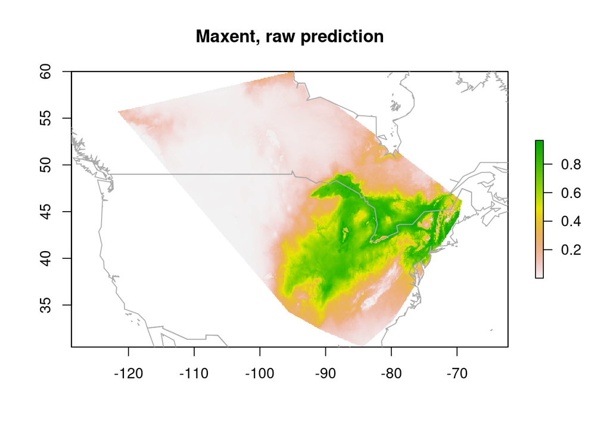

```r
y_maxv <- predict(env_stack, mdl_maxv) #, ext=ext, progress='')

plot(y_maxv, main='Maxent, raw prediction')
data(wrld_simpl, package="maptools")
plot(wrld_simpl, add=TRUE, border='dark grey')
```

# 4 Evaluate

## 4.1 Area Under the Curve (AUC), Receiver Operator Characteristic (ROC) Curve, and Confusion Matrix

- split the test data into presence and absence
- use `dismo()` to calculate the AUC and max TPR + TNR

```r
pts_test_p <- pts_test %>%
  filter(present == 1) %>%
  as_Spatial()
pts_test_a <- pts_test %>%
  filter(present == 0) %>%
  as_Spatial()

y_maxv <- predict(mdl_maxv, env_stack)
#plot(y_maxv)

e <- dismo::evaluate(
  p     = pts_test_p,
  a     = pts_test_a,
  model = mdl_maxv,
  x     = env_stack)
e
```

```
## class          : ModelEvaluation
## n presences    : 156
## n absences     : 156
## AUC            : 0.8720003
## cor            : 0.645805
## max TPR+TNR at : 0.4665749
```

## 4.2 Plot the ROC Curve

- identify the threshold and mark it in blue on the plot

```r
#plot(e, 'ROC')

thr <- threshold(e)[['spec_sens']]
thr
```

```
## [1] 0.4665749
```

## 4.3 Create the Confusion Matrix

```r
p_true <- na.omit(extract(y_maxv, pts_test_p) >= thr)
a_true <- na.omit(extract(y_maxv, pts_test_a) < thr)

# (t)rue/(f)alse (p)ositive/(n)egative rates
tpr <- sum(p_true)/length(p_true)
fnr <- sum(!p_true)/length(p_true)
fpr <- sum(!a_true)/length(a_true)
tnr <- sum(a_true)/length(a_true)

matrix(
  c(tpr, fnr,
    fpr, tnr),
  nrow=2, dimnames = list(
    c("present_obs", "absent_obs"),
    c("present_pred", "absent_pred")))
```

```
##             present_pred absent_pred
## present_obs    0.8846154   0.2628205
## absent_obs     0.1153846   0.7371795
```

```r
plot(e, 'ROC')

thr <- threshold(e)[['spec_sens']]
thr
```

```
## [1] 0.4665749
```

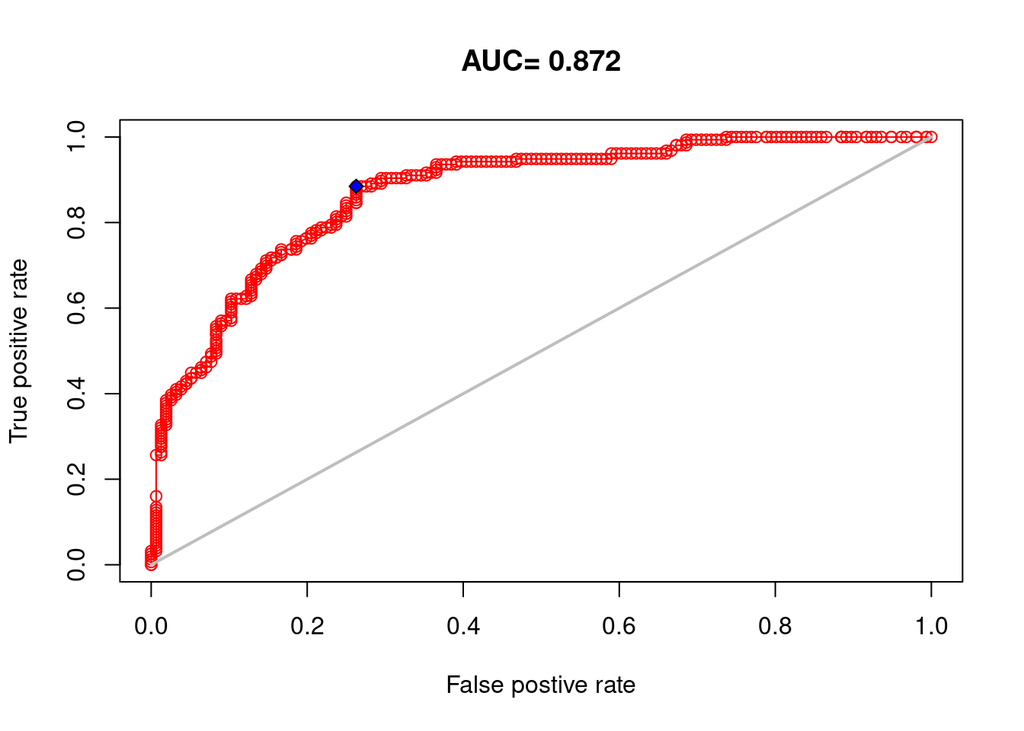

```r
points(fpr, tpr, pch=23, bg="blue")
```

## 4.4 Plot the areas where we predict *Necturus maculosus* presence

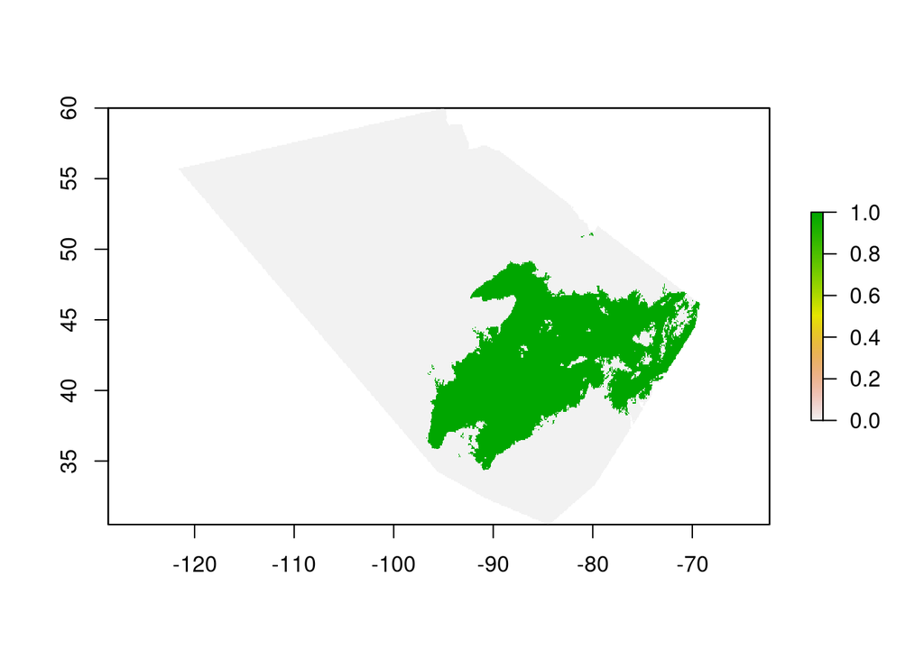

```r
plot(y_maxv > thr)
```